# Lab 9: Reproducible Reporting with `{papaja}`

Prior to today’s lab, make sure that you have installed [LaTeX](https://www.latex-project.org/get/). You can download the Rmd file here and the example `{papaja}` .Rmd file here.

# Purpose

The following lab covers `{papaja}`, a package for creating reproducible, APA-style manuscripts in Rmarkdown. We will go over how to write a manuscript in `{papaja}`, including creating tables, figures, citations, and in-text statistical reporting. This page has some broad (overview) information and links to useful resources.

# What is `{papaja}`?

`{papaja}` is an R package for **P**reparing **APA** **J**ournal **A**rticles. It contains several functions and perhaps most importantly, an .Rmd template that formats an output document (.docx or .pdf) in APA format. Here is the link to [papaja’s documentation](https://crsh.github.io/papaja_man/index.html), the most helpful and comprehensive `{papaja}` resource out there.

# Installing `{papaja}`

First, we need to install `{papaja}`. `{papaja}` is not yet on CRAN, so we have to download it from GitHub rather than using `install.packages()`. This requires the `{devtools}` package. Let’s install both `{devtools}` and `{papaja}`.

```r
# install the devtools package if necessary
if(!"devtools" %in% rownames(installed.packages())) install.packages("devtools")

# install the stable development version of papaja from GitHub if necessary
if(!"papaja" %in% rownames(installed.packages())) devtools::install_github("crsh/papaja")

# load papaja
library(papaja)
```

In addition to `{papaja}`, the `{citr}` package is going to be helpful when it comes to citing works in text (within our .Rmd) and the `{corx}` package is going to make it easier to create a table of correlations.

```r
# install the citr package if necessary
if(!"citr" %in% rownames(installed.packages())) devtools::install_github("crsh/citr")

# install the corx package if necessary
if(!"corx" %in% rownames(installed.packages())) install.packages("corx")

# load corx
library(corx)
```

OK, now we’re ready to go! Below I’ll briefly review some of the functions we’ll be using today before we dive into hands-on work in a `{papaja}` template .Rmd.

# Inserting object values in text

The information covered in this section is not specific to `{papaja}`, but it will be very useful when it comes to preparing manuscripts using `{papaja}`.

To insert a value stored within an object into text in Rmarkdown, you can write it as “r name_of_object” (replacing the quotes with back ticks; i.e., `).

For example, if you stored the value `5` in an object called `x` you would write “r x” (replacing the quotes with back ticks) to have the number 5 inserted in the text when you knit the Rmarkdown document.

# Tables

There are a few options for making APA-style tables in `{papaja}`, each of which has different strengths and weaknesses.

We’ll start by going over `apa_table()` from `{papaja}`.`apa_table()` can be used to format a dataframe as an APA-style table. It is built on top of `knitr::kable()`. When using `apa_table()`, the workflow generally goes something like:

1. Create a dataframe that contains everything you want in the table.
2. use `printnum()` (from `{papaja}`) to format the numeric columns.
3. Pass this formatted dataframe to `apa_table()`, and set the caption and note (if applicable).
4. Always **set the chunk option `results = "asis"`**.

## Table of descriptives

Let’s start by getting a table of descriptive stats. We’ll use the `bfi` data from the `{psych}` package and use `bfi.keys` to score the five scale scores.

```r
b5 <- bfi %>%
  cbind(scoreVeryFast(keys = bfi.keys, items = bfi))
```

First, we create a dataframe with the descriptive statistics of our Big Five scales. We’ll use some of the `{dplyr}` functions for this.

```r
descriptives <- b5 %>%
  # select the columns for agreeableness to openness
  select(agree:openness) %>%
  # convert into long format
  gather(scale, score) %>%
  # group_by trait
  group_by(scale) %>%
  # calculate the mean, median, sd, min, and max for each trait
  summarize(
    Mean   = mean(score),
    Median = median(score),
    SD     = sd(score),
    Min    = min(score),
    Max    = max(score))
```

Next, we format the numerical columns using `printnum()` function from `{papaja}` for this. In essence, this puts everything to 2 decimal points (you can change this), pads with zeroes when necessary, and turns those to strings so they print correctly. “-1” indicates that the first column is non-numerical so does not apply.

```r
descriptives <- descriptives %>%
  # if the column is numeric, apply the printnum function
  mutate_if(is.numeric, printnum)
```

Then, we run `apa_table()` on the dataframe, and we can add a caption and note. You have to set `results = "asis"` in the chunk options for it to render correctly:

```r
apa_table(descriptives,
          caption = "Descriptive statistics of Big Five Scale Scores.",
          note    = "This table was created with apa_table().")
```

(#tab:descrips-tab)

*Descriptive statistics of Big Five Scale Scores.*

| scale | Mean | Median | SD | Min | Max |
| --- | --- | --- | --- | --- | --- |
| agree | 4.65 | 4.80 | 0.90 | 1.00 | 6.00 |
| conscientious | 4.27 | 4.40 | 0.95 | 1.00 | 6.00 |
| extraversion | 4.15 | 4.20 | 1.06 | 1.00 | 6.00 |
| neuroticism | 3.16 | 3.00 | 1.20 | 1.00 | 6.00 |
| openness | 4.59 | 4.60 | 0.81 | 1.20 | 6.00 |

*Note.* This table was created with apa_table().

Now we have a nicely formatted APA-style table that is fully reproducible.

## Table of correlations

Next, let’s get a table of scale inter-correlations for the same dataset. Correlation tables are a little difficult in `{papaja}`, but the `corx()` function from the `{corx}` package makes it a little easier.

Basically, the workflow for this is:

1. Use `corx()` to create the correlation table.
2. Use `apa_table()` to add a caption, note, and print it.

```r
cor <- b5 %>%
  # select the columns for agreeableness to openness
  select(agree:openness) %>%
  # create the correlation matrix
  corx(triangle = "lower",
       stars    = c(0.05, 0.01, 0.001),
       describe = c(M = mean, SD = sd))

apa_table(cor$apa,
          caption = "Example correlation matrix",
          note    = "* p < 0.05; ** p < 0.01; *** p < 0.001")
```

(#tab:corr_tab)

*Example correlation matrix*

|  | 1 | 2 | 3 | 4 | M | SD |
| --- | --- | --- | --- | --- | --- | --- |
| 1. agree | - |  |  |  | 4.65 | 0.90 |
| 2. conscientious | .26*** | - |  |  | 4.27 | 0.95 |
| 3. extraversion | .46*** | .26*** | - |  | 4.15 | 1.06 |
| 4. neuroticism | -.19*** | -.23*** | -.22*** | - | 3.16 | 1.20 |
| 5. openness | .15*** | .20*** | .21*** | -.09*** | 4.59 | 0.81 |

*Note.* * p < 0.05; ** p < 0.01; *** p < 0.001

## Regression tables

Now we’ll get a regression table using another method available in `{papaja}`. We’ll use the `apa_print()` function. This function takes statistical results as input and produces a list containing an APA-style table and several objects useful for printing results in-text (covered below).

The workflow for this method is:

1. Conduct statistical test(s).
2. Create the APA-style results with `apa_print()`.
3. Extract the table from the `apa_print()` object with `$table`.

Let’s do that with two regression models. Let’s regress `conscientious` on `age` (model 1) and `conscientious` on `age` *and* `education` (model 2).

First, fit the two regression models.

```r
# tidy the data
b5 <- b5 %>%
  # convert education to a factor
  mutate(education = case_when(education == 1 ~ "Some HS",
                               education == 2 ~ "Finished HS",
                               education == 3 ~ "Some College",
                               education == 4 ~ "College Grad",
                               education == 5 ~ "Grad Degree"),
         education = factor(education,
                            levels = c("Some HS",
                                       "Finished HS",
                                       "Some College",
                                       "College Grad",
                                       "Grad Degree")),) %>%
  # remove rows where conscientiousness, age, or education are NA
  filter(!is.na(conscientious),
         !is.na(age),
         !is.na(education))

# fit the regression models
model_1 <- lm(conscientious ~ age,             data = b5)
model_2 <- lm(conscientious ~ age + education, data = b5)
```

Next, use `apa_print()` to create those APA-style results objects:

```r
# model 1 results
model_1_results <- apa_print(model_1)

# model 2 results
model_2_results <- apa_print(model_2)

# model comparison results
model_comp_results <- apa_print(list(model_1,
                                     model_2),
                                boot_samples = 0)
```

*Note*: If we didn’t set `boot_samples = 0`, `apa_print()` would have produced bootstrapped CIs for the $\Delta R^2$s. We will cover bootstrapping next week.

After we have used `apa_print()` to create the results objects, we can extract the APA tables.

You could get a table for just the Model 1 results using the code below:

```r
model_1_results$table %>%
  apa_table(caption = "Model Regressing Conscientiousness on Age",
            note    = "* p < 0.05; ** p < 0.01; *** p < 0.001")
```

(#tab:reg-tbl-1)

*Model Regressing Conscientiousness on Age*

| Predictor | $b$ | 95% CI | $t(2575)$ | $p$ |
| --- | --- | --- | --- | --- |
| Intercept | 4.07 | $[3.96$, $4.17]$ | 75.42 | < .001 |
| Age | 0.01 | $[0.00$, $0.01]$ | 4.71 | < .001 |

*Note.* * p < 0.05; ** p < 0.01; *** p < 0.001

Or we could get a table for just the Model 2 results:

```r
model_2_results$table %>%
  apa_table(caption = "Model Regressing Conscientiousness on Age & Education",
            note = "* p < 0.05; ** p < 0.01; *** p < 0.001")
```

(#tab:reg-tbl-2)

*Model Regressing Conscientiousness on Age & Education*

| Predictor | $b$ | 95% CI | $t(2571)$ | $p$ |
| --- | --- | --- | --- | --- |
| Intercept | 3.87 | $[3.72$, $4.02]$ | 50.43 | < .001 |
| Age | 0.01 | $[0.01$, $0.01]$ | 5.54 | < .001 |
| EducationFinished HS | 0.05 | $[-0.12$, $0.21]$ | 0.54 | .588 |
| EducationSome College | 0.25 | $[0.11$, $0.38]$ | 3.63 | < .001 |
| EducationCollege Grad | 0.02 | $[-0.13$, $0.18]$ | 0.28 | .782 |
| EducationGrad Degree | 0.06 | $[-0.09$, $0.22]$ | 0.79 | .430 |

*Note.* * p < 0.05; ** p < 0.01; *** p < 0.001

Finally, we can get these results together using the table stored in `model_comp_results`:

```r
model_comp_results$table %>%
  apa_table(caption = "Model Comparison: Conscientiousness by Age and Age + Education",
            note    = "* p < 0.05; ** p < 0.01; *** p < 0.001")
```

(#tab:reg-tbl-3)

*Model Comparison: Conscientiousness by Age and Age + Education*

|  | Model 1 | Model 2 |
| --- | --- | --- |
| Intercept | $4.07$ $[3.96$, $4.17]$ | $3.87$ $[3.72$, $4.02]$ |
| Age | $0.01$ $[0.00$, $0.01]$ | $0.01$ $[0.01$, $0.01]$ |
| EducationCollege Grad |  | $0.02$ $[-0.13$, $0.18]$ |
| EducationFinished HS |  | $0.05$ $[-0.12$, $0.21]$ |
| EducationGrad Degree |  | $0.06$ $[-0.09$, $0.22]$ |
| EducationSome College |  | $0.25$ $[0.11$, $0.38]$ |
| $R^2$ [90% CI] | $.01$ $[0.00$, $0.02]$ | $.02$ $[0.01$, $0.03]$ |
| $F$ | 22.16 | 10.93 |
| $df_1$ | 1 | 5 |
| $df_2$ | 2575 | 2571 |
| $p$ | < .001 | < .001 |
| $\mathrm{AIC}$ | 6,979.81 | 6,955.69 |
| $\mathrm{BIC}$ | 6,997.38 | 6,996.68 |
| $\Delta R^2$ |  | $.01$ |
| $F$ |  | 8.06 |
| $df_1$ |  | 4 |
| $df_2$ |  | 2,571 |
| $p$ |  | < .001 |
| $\Delta \mathrm{AIC}$ |  | -24.12 |
| $\Delta \mathrm{BIC}$ |  | -0.70 |

*Note.* * p < 0.05; ** p < 0.01; *** p < 0.001

The last thing I’ll mention here is that we can use the chunk labels for our table to reference them in text. For example, we could reference this last table by adding `Table \@ref(tab:reg-tbl-3)` in the `{papaja}` .Rmd.

# Figures

You can also create figures in `{papaja}` manuscripts by using practically any of the methods you already know. I personally like `{ggplot}`, which can be put into APA format by using the `theme_apa()` function from `{papaja}`.

Let’s create an APA-formatted plot for the relation between `age` and `conscientious`.

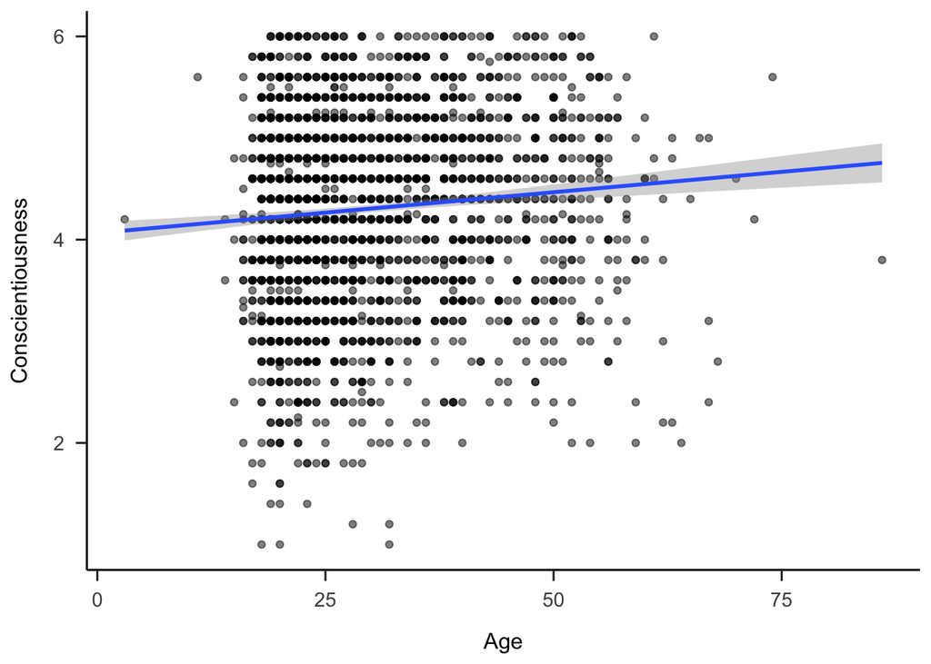

```r
ggplot(b5, aes(x = age, y = conscientious)) +
  geom_point(alpha   = .5) +
  geom_smooth(method = "lm") +
  labs(x = "Age",
       y = "Conscientiousness") +
  theme_apa()
```

The best way to give the figure a caption is to preface it with:

(ref:fig-ageXconsc-cap) Conscientiousness by Age.

You then set the chunk option `fig.cap = "(ref:fig-ageXconsc-cap) "`. There is an example of this in the example `{papaja}` .Rmd, so we will see it in action in a moment.

We are able to extend this process of creating a figure to more complicated plots. For example, let’s add `education` to the figure.

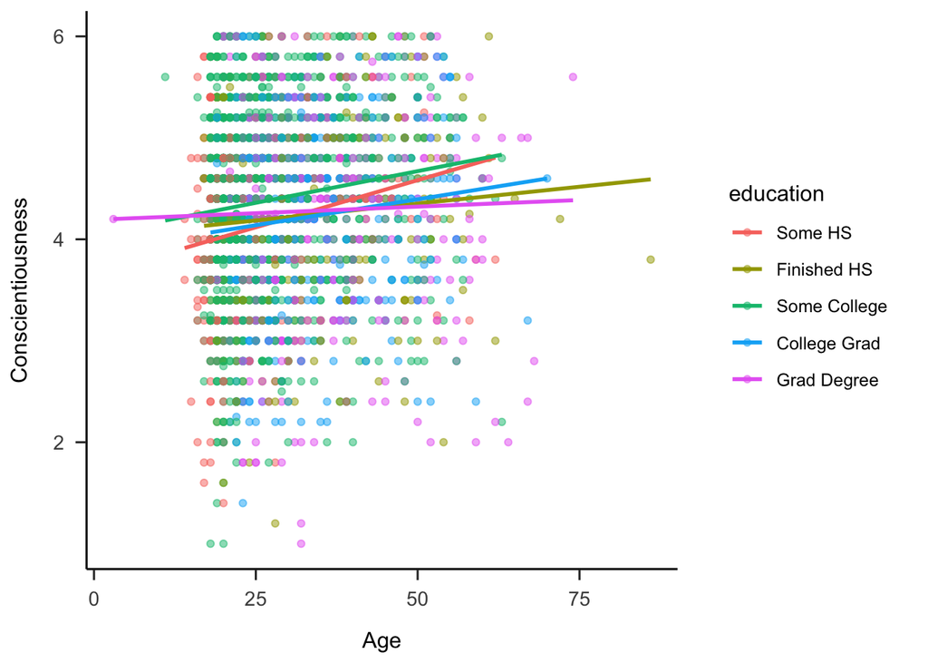

```r
ggplot(b5, aes(x = age, y = conscientious, color = education)) +
  geom_point(alpha   = .5) +
  geom_smooth(method = "lm", se = FALSE) +
  labs(x = "Age",
       y = "Conscientiousness") +
  theme_apa()
```

Or one that has `age` by each of the Big Five personality traits:

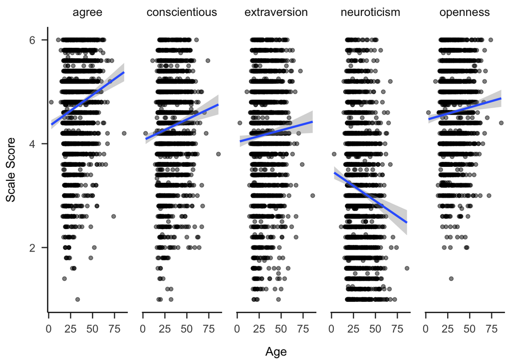

```r
b5 %>%
  select(age, agree:openness) %>%
  gather(trait, score, -age) %>%
  ggplot(aes(x = age, y = score)) +
    geom_point(alpha   = .5) +
    geom_smooth(method = "lm") +
    labs(x = "Age",
         y = "Scale Score") +
  facet_grid(~trait) +
  theme_apa()
```

# In-text summaries of tests

One of the most useful aspects of writing manuscripts in .Rmd and `{papaja}` is that we can report our results directly from the statistical models we run in R, reducing the likelihood of copy-and-pasting errors.

We can use `apa_print()` from `{papaja}` to report the results of our statistical tests in text. Abbreviated results (estimate and CI) can be called with `$estimate` from the `apa_print()` object. For example, `model_1_results$estimate$age` will print a nicely formatted printout of the slope for age on conscientiousness:

> Age significantly predicted conscientiousness, $b = 0.01$, 95% CI $[0.00$, $0.01]$.

We can instead get the full result (including *t*, *df*, and *p*) by calling the `$full_result` object, so `model_1_results$full_result$age` will be rendered like so:

> Age significantly predicted conscientiousness, $b = 0.01$, 95% CI $[0.00$, $0.01]$, $t(2575) = 4.71$, $p < .001$.

We could get the results of other slopes by changing out `$age` to reference other terms. For example, we could report the result of the difference between some high school and having finished high school with `model_2_results$full_result$educationFinished_HS`:

> Finishing highschool (vs. not finishing highschool) was not associated with Conscientiousness, $b = 0.05$, 95% CI $[-0.12$, $0.21]$, $t(2571) = 0.54$, $p = .588$.

## Regression model results

We can also get model fit results, for both the individual models and for the comparison object. For example:

- `model_1_results$full_result$modelfit$r2` will print the $R^2$ for model 1.
- `model_2_results$full_result$modelfit$r2` will print the $R^2$ for model 2.
- `model_comp_results$full_result$model2` will print the $\Delta R^2$ value (difference in $R^2$), and the *F* test for that difference.

`{papaja}` has various print methods, so be sure to check out [the documentation](https://crsh.github.io/papaja_man/reporting.html#results-from-statistical-tests).

# Bibliography

The final ingredient we will talk about before getting into our example manuscript and the (singular) hack for the lab is the bibliography. All RMDs can include a `bibliography:` entry in the YAML (the header portion of an .Rmd), where you can link to a BibTeX (i.e., `.bib`) file. Bibtex entries look something like this:

```
@article{goldberg1990alternative,
  title={An alternative" description of personality": the big-five factor structure.},
  author={Goldberg, Lewis R},
  journal={Journal of personality and social psychology},
  volume={59},
  number={6},
  pages={1216--1229},
  year={1990},
  doi = {https://doi.org/10.1037/0022-3514.59.6.1216},
  publisher={American Psychological Association}
}
```

## Creating a BibTeX file for references

One convenient thing, is that you can get them from [Google Scholar](https://scholar.google.com). Let’s take a look at the scholar results when we search for [McClelland & Judd (1993)](https://scholar.google.com/scholar?q=author%3AMcClelland+author%3AJudd&hl=en&as_sdt=0%2C38&as_ylo=1993&as_yhi=1993).

From there, click on the quotes, and then on the BibTeX link, which takes you here

You should see this:

```
@article{mcclelland1993statistical,
  title={Statistical difficulties of detecting interactions and moderator effects.},
  author={McClelland, Gary H and Judd, Charles M},
  journal={Psychological bulletin},
  volume={114},
  number={2},
  pages={376},
  year={1993},
  publisher={American Psychological Association}
}
```

You can also use popular reference managers like Mendeley or Zotero to create BibTeX files.

## In-text citations

Then, we could reference this article by referring to its name. There are basically three options:

| Type | code | how it renders |
| --- | --- | --- |
| Parenthetical citation | `[@mcclelland1993statistical]` | (McClelland and Judd 1993) |
| Non-parenthetical | `@mcclelland1993statistical` | McClelland and Judd (1993) |
| just the year | `[-@mcclelland1993statistical]`. | (1993) |

Note that you can also put additional text in the brackets. For example,

`[see @mcclelland1993statistical]`

becomes…

(see McClelland and Judd 1993)

You can also add multiple citations by separating them with a `;`. For example,

`[@mcclelland1993statistical; @cohen2013applied]`

becomes…

(McClelland and Judd 1993; Cohen et al. 2013)

One of the coolest things about using BibTeX is that references will only appear in your reference list that you cite in text! You can see that here, because the ‘lab-9.bib’ file has four entries and the reference list below has just the two we reference above. That means no more last-minute checks on the reference list to make sure you removed the articles you references in a previous draft (that are no longer referenced). This alone is a huge time saver.

## Citing R packages (& Helper functions from `{papaja}`)

`{papaja}` makes it easy to cite any R package you’ve used with the `r_refs(file = "r-references.bib")`, which creates a .bib file (named r-references.bib in that example code) with BibTeX entries for all R packages you’ve called in the script. It is super handy!

You can combine this with the `{cite_r()}` package from `{papaja}`, which will create an in-text citation of all the packages you’ve used - we’ll see this in the example `{papaja}` .Rmd

That is all for this tutorial. Now let’s turn to the example .Rmd, and finally work on the hack (time permitting)!

# The single `{papaja}` hack

Today there is just one hack. For this hack, we want you to get started on your final project .Rmd.

1. Create a new .Rmd file for your final project using the `{papaja}` template.
2. Edit the YAML to have the title and author of your project
- Don’t worry about the abstract for now, unless you’ve already written it
3. Create a .bib file with at least one reference you know you’ll need for your final project.
4. Cite the reference from your .bib (part 3) in text.
5. Run at least one statistical test.
6. Report the statistical test from part 4 in-text, in a table, and in a figure.
- If you don’t have your data yet, run a similar test with a built-in dataset or one from a prior lab. The more similar the better - it will make it easier for you to adapt the code for your own data.
- Bonus points if you can reference the table and figure in-text.

# References

Cohen, Jacob, Patricia Cohen, Stephen G West, and Leona S Aiken. 2013. *Applied Multiple Regression/Correlation Analysis for the Behavioral Sciences*. Routledge.

McClelland, Gary H, and Charles M Judd. 1993. “Statistical Difficulties of Detecting Interactions and Moderator Effects.” *Psychological Bulletin* 114 (2): 376.